# ML practice 8. Part 2: Dimensionality Reduction

Продолжаем говорить о том, какие еще существуют методы для того, чтобы сократить количество переменных, включаемых в модель. Мы обсудили методы, позволяющие отобрать только часть переменных, сегодня разбираем другой подход, осонованный на построении комбинаций из переменных

### Данные (колледжи)

Загружаем данные

```r
library(ISLR)
data <- College
```

Посмотрим на них

```r
str(data)
```

```
## 'data.frame':    777 obs. of  18 variables:
##  $ Private    : Factor w/ 2 levels "No","Yes": 2 2 2 2 2 2 2 2 2 2 ...
##  $ Apps       : num  1660 2186 1428 417 193 ...
##  $ Accept     : num  1232 1924 1097 349 146 ...
##  $ Enroll     : num  721 512 336 137 55 158 103 489 227 172 ...
##  $ Top10perc  : num  23 16 22 60 16 38 17 37 30 21 ...
##  $ Top25perc  : num  52 29 50 89 44 62 45 68 63 44 ...
##  $ F.Undergrad: num  2885 2683 1036 510 249 ...
##  $ P.Undergrad: num  537 1227 99 63 869 ...
##  $ Outstate   : num  7440 12280 11250 12960 7560 ...
##  $ Room.Board : num  3300 6450 3750 5450 4120 ...
##  $ Books      : num  450 750 400 450 800 500 500 450 300 660 ...
##  $ Personal   : num  2200 1500 1165 875 1500 ...
##  $ PhD        : num  70 29 53 92 76 67 90 89 79 40 ...
##  $ Terminal   : num  78 30 66 97 72 73 93 100 84 41 ...
##  $ S.F.Ratio  : num  18.1 12.2 12.9 7.7 11.9 9.4 11.5 13.7 11.3 11.5 ...
##  $ perc.alumni: num  12 16 30 37 2 11 26 37 23 15 ...
##  $ Expend     : num  7041 10527 8735 19016 10922 ...
##  $ Grad.Rate  : num  60 56 54 59 15 55 63 73 80 52 ...
```

У нас есть 18 параметров, характеризующих колледжи:

- `Private` A factor with levels No and Yes indicating private or public university
- `Apps` Number of applications received
- `Accept` Number of applications accepted
- `Enroll` Number of new students enrolled
- `Top10perc` Pct. new students from top 10% of H.S. class
- `Top25perc` Pct. new students from top 25% of H.S. class
- `F.Undergrad` Number of fulltime undergraduates
- `P.Undergrad` Number of parttime undergraduates
- `Outstate` Out-of-state tuition
- `Room.Board` Room and board costs
- `Books` Estimated book costs
- `Personal` Estimated personal spending
- `PhD` Pct. of faculty with Ph.D.’s
- `Terminal` Pct. of faculty with terminal degree
- `S.F.Ratio` Student/faculty ratio
- `perc.alumni` Pct. alumni who donate
- `Expend` Instructional expenditure per student
- `Grad.Rate` Graduation rate

### Анализ главных компонент (Principal Component Analysis)

Общая идея методов уменьшения размерности – использовать взаимосвязи, которые есть в данных. Зная взаимосвязи, мы можем выразить несколько признаков через один и работать уже с более простой моделью. Конечно, избежать потерь информации, скорее всего не удастся, но можно постараться ее минимизировать.

Метод главных компонент (англ. principal component analysis, PCA) — способ уменьшить размерность данных, потеряв наименьшее количество информации. Подробнее про метод можно почитать в книге Exploratory Data Analysis (она есть в shared/minor3_2017/books)

В PCA данные преобразуются таким образом, чтобы новые переменные (компоненты, построенные в виде комбинации из первоначальных переменных) наилучшим образом описывали изменчивость в данных (другими словами – мы выбираем наиболее “загруженное” направление)

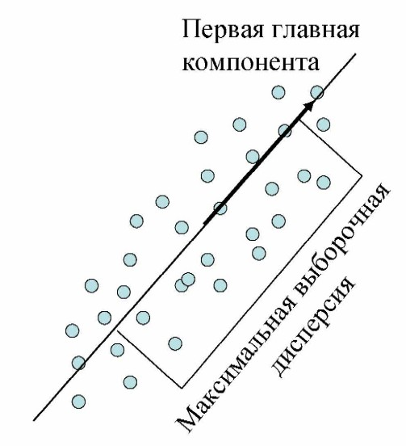

```r
data.pca <- prcomp(dplyr::select(data,-Private),
                 center = TRUE,
                 scale. = TRUE)
data.pca
```

```
## Standard deviations (1, .., p=17):
##  [1] 2.3331324 2.1160899 1.0831232 1.0034481 0.9659342 0.9205429 0.7778227
##  [8] 0.7662347 0.7279627 0.6354389 0.5595020 0.4693901 0.4093632 0.3792007
## [15] 0.2964985 0.1915155 0.1516517
##
## Rotation (n x k) = (17 x 17):
##                     PC1         PC2         PC3         PC4         PC5
## Apps         0.24876560 -0.33159823  0.06309210 -0.28131053 -0.00574141
## Accept       0.20760150 -0.37211675  0.10124906 -0.26781735 -0.05578609
## Enroll       0.17630359 -0.40372425  0.08298557 -0.16182677  0.05569364
## Top10perc    0.35427395  0.08241182 -0.03505553  0.05154725  0.39543434
## Top25perc    0.34400128  0.04477866  0.02414794  0.10976654  0.42653359
## F.Undergrad  0.15464096 -0.41767377  0.06139298 -0.10041234  0.04345437
## P.Undergrad  0.02644250 -0.31508783 -0.13968172  0.15855849 -0.30238541
## Outstate     0.29473642  0.24964352 -0.04659887 -0.13129136 -0.22253200
## Room.Board   0.24903045  0.13780888 -0.14896739 -0.18499599 -0.56091947
## Books        0.06475752 -0.05634184 -0.67741165 -0.08708922  0.12728883
## Personal    -0.04252854 -0.21992922 -0.49972112  0.23071057  0.22231102
## PhD          0.31831287 -0.05831132  0.12702837  0.53472483 -0.14016633
## Terminal     0.31705602 -0.04642945  0.06603755  0.51944302 -0.20471973
## S.F.Ratio   -0.17695789 -0.24666528  0.28984840  0.16118949  0.07938825
## perc.alumni  0.20508237  0.24659527  0.14698927 -0.01731422  0.21629741
## Expend       0.31890875  0.13168986 -0.22674398 -0.07927349 -0.07595812
## Grad.Rate    0.25231565  0.16924053  0.20806465 -0.26912907  0.10926791
##                      PC6          PC7          PC8          PC9
## Apps        -0.016237442 -0.042486349  0.103090398 -0.090227080
## Accept       0.007534685 -0.012949720  0.056270962 -0.177864814
## Enroll      -0.042557980 -0.027692894 -0.058662355 -0.128560713
## Top10perc   -0.052692798 -0.161332069  0.122678028  0.341099863
## Top25perc    0.033091590 -0.118485556  0.102491967  0.403711989
## F.Undergrad -0.043454235 -0.025076363 -0.078889644 -0.059441918
## P.Undergrad -0.191198583  0.061042346 -0.570783816  0.560672902
## Outstate    -0.030000391  0.108528966 -0.009845998 -0.004573329
## Room.Board   0.162755446  0.209744235  0.221453442  0.275022548
## Books        0.641054950 -0.149692034 -0.213293009 -0.133663353
## Personal    -0.331398003  0.633790064  0.232660840 -0.094468890
## PhD          0.091255521 -0.001096413  0.077040000 -0.185181525
## Terminal     0.154927646 -0.028477011  0.012161330 -0.254938198
## S.F.Ratio    0.487045875  0.219259358  0.083604874  0.274544380
## perc.alumni -0.047340014  0.243321156 -0.678523654 -0.255334907
```

[output cut: 23 more lines]

```
## Enroll      -0.029589609  0.404318439 -0.609651110
## Top10perc   -0.697722522  0.148738723  0.144986329
## Top25perc    0.617274818 -0.051868340 -0.080347844
## F.Undergrad -0.009916410 -0.560363054  0.414705279
## P.Undergrad -0.020951598  0.052731304 -0.009017890
## Outstate    -0.038354479 -0.101594830 -0.050899592
## Room.Board  -0.003401971  0.025929338 -0.001146396
## Books        0.009438879 -0.002882829 -0.000772632
## Personal     0.003090014  0.012890402  0.001114334
## PhD          0.112055599 -0.029807547 -0.013813337
## Terminal    -0.158909651  0.027075981 -0.006209327
## S.F.Ratio    0.020899128  0.021247629  0.002222152
## perc.alumni  0.008417894 -0.003334062  0.019186974
## Expend       0.227742017  0.043880323  0.035309822
## Grad.Rate    0.003394336  0.005008447  0.013071002
```

- Зачем нужна нормализация?

Изменчивость данных, объясняемая компонентами

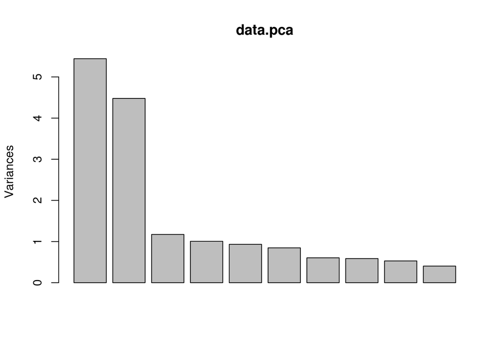

```r
plot(data.pca)
```

Суммарную долю объясненной изменчивости можно посмотреть с помощью функции `summary()`

```r
summary(data.pca)
```

```
## Importance of components:
##                           PC1    PC2     PC3     PC4     PC5     PC6
## Standard deviation     2.3331 2.1161 1.08312 1.00345 0.96593 0.92054
## Proportion of Variance 0.3202 0.2634 0.06901 0.05923 0.05488 0.04985
## Cumulative Proportion  0.3202 0.5836 0.65262 0.71185 0.76673 0.81658
##                            PC7     PC8     PC9    PC10    PC11    PC12
## Standard deviation     0.77782 0.76623 0.72796 0.63544 0.55950 0.46939
## Proportion of Variance 0.03559 0.03454 0.03117 0.02375 0.01841 0.01296
## Cumulative Proportion  0.85217 0.88670 0.91788 0.94163 0.96004 0.97300
##                           PC13    PC14    PC15    PC16    PC17
## Standard deviation     0.40936 0.37920 0.29650 0.19152 0.15165
## Proportion of Variance 0.00986 0.00846 0.00517 0.00216 0.00135
## Cumulative Proportion  0.98286 0.99132 0.99649 0.99865 1.00000
```

Вернемся к машинному обучению

### Обучающая и тестовая выборки

```r
set.seed(345)
data.test.ind = sample(seq_len(nrow(data)), size = nrow(data)*0.2)
data.test = data[data.test.ind,]
data.main = data[-data.test.ind,]
```

### PCA в пакете `caret`

С помощью пакета `caret` выполняем PCA, не забывая про нормализацию переменных. Подробнее про предобработку переменных в пакете `caret` можно посмотреть в [документации](https://topepo.github.io/caret/pre-processing.html)

```r
library(caret)
preprocessParams <- preProcess(data.main, method=c("center", "scale", "pca"))
# summarize transform parameters
preprocessParams
```

```
## Created from 622 samples and 18 variables
##
## Pre-processing:
##   - centered (17)
##   - ignored (1)
##   - principal component signal extraction (17)
##   - scaled (17)
##
## PCA needed 11 components to capture 95 percent of the variance
```

По умолчанию функция оставляет столько компонент, сколько покрывают 95% изменчивости данных, но этот параметр можно менять. То, как исходные переменные вносят вклад в каждую из компонент, можно посмотреть в переменной `rotation`

```r
preprocessParams$rotation
```

```
##                     PC1         PC2         PC3         PC4         PC5
## Apps         0.24785683 -0.33050386  0.05886024 -0.27578349  0.04453176
## Accept       0.20457646 -0.37340639  0.09329770 -0.25321444  0.10703524
## Enroll       0.17496426 -0.40417463  0.08557871 -0.16561753 -0.02967115
## Top10perc    0.35378964  0.08335498  0.01060849 -0.02388783 -0.41787157
## Top25perc    0.34432382  0.05149852  0.08770203  0.03061786 -0.42816108
## F.Undergrad  0.15213141 -0.41855035  0.06367048 -0.09971386 -0.02648913
## P.Undergrad  0.02364346 -0.31585548 -0.16951616  0.21868668  0.27231479
## Outstate     0.29249528  0.25299371 -0.07172029 -0.08289336  0.24840024
## Room.Board   0.25418669  0.13428581 -0.20510523 -0.07756610  0.56453137
## Books        0.06213350 -0.06193318 -0.63528826 -0.18110776 -0.05779995
## Personal    -0.03795449 -0.22128539 -0.45848096  0.23005524 -0.35307897
## PhD          0.32035789 -0.06050944  0.10658610  0.54673671  0.05368606
## Terminal     0.32002039 -0.04709160  0.04957395  0.53381863  0.14634888
## S.F.Ratio   -0.17814808 -0.24246796  0.33161344  0.10381366  0.03781694
## perc.alumni  0.19933190  0.24850917  0.18678224 -0.07570791 -0.12907019
## Expend       0.31281644  0.12628964 -0.26019889 -0.07200302 -0.01262442
## Grad.Rate    0.26237800  0.16189953  0.22919166 -0.26254894  0.04395089
##                     PC6          PC7          PC8         PC9         PC10
## Apps         0.05076188 -0.001866301  0.107498580 -0.09817661  0.062898187
## Accept       0.03655378  0.006866014  0.042898203 -0.18986743  0.044720909
## Enroll       0.06477828  0.055626409 -0.063078369 -0.11036944  0.022229040
## Top10perc   -0.03132756  0.039353548  0.184034931  0.33617797  0.075677078
## Top25perc   -0.14047345 -0.015122887  0.156515293  0.38381089 -0.006356744
## F.Undergrad  0.05762557  0.065869173 -0.061515957 -0.03374977  0.021462709
## P.Undergrad  0.22576850  0.099842160 -0.399452917  0.65348690 -0.261141763
## Outstate     0.06161181 -0.095501838 -0.064038946 -0.02878071  0.170453397
## Room.Board  -0.08042759 -0.329063192  0.193164393  0.20924771  0.293797501
## Books       -0.65618421  0.261870388 -0.199799617 -0.07917884 -0.061555699
## Personal     0.20859649 -0.672697202 -0.131431337 -0.16796647  0.123665583
## PhD         -0.12214180  0.061399111  0.035767165 -0.20476493 -0.075937267
## Terminal    -0.15078516  0.092569043 -0.005945166 -0.25495731 -0.070588054
## S.F.Ratio   -0.48851268 -0.241787940 -0.036446686  0.23568492  0.476221212
## perc.alumni  0.08800327  0.090263816 -0.773295890 -0.10203680  0.379804676
## Expend       0.32573304  0.173693105  0.141204527 -0.02099422  0.162193424
## Grad.Rate   -0.20587293 -0.482858697 -0.204294837 -0.03454249 -0.613660278
##                    PC11
## Apps        -0.03030655
## Accept       0.07241703
## Enroll       0.07012240
## Top10perc    0.02940722
## Top25perc    0.23242869
## F.Undergrad  0.08178486
## P.Undergrad -0.08926388
## Outstate    -0.12019915
## Room.Board   0.35955335
## Books       -0.02807811
## Personal     0.01075469
## PhD         -0.03025892
## Terminal     0.02363092
## S.F.Ratio   -0.45199565
## perc.alumni  0.15149499
## Expend      -0.69560294
## Grad.Rate   -0.24931245
```

Затем мы используем полученные зависимости, чтобы преобразовать обучающую и тестовую выборки

```r
# transform the dataset using the parameters
transformed.main <- predict(preprocessParams, data.main)
transformed.test <- predict(preprocessParams, data.test)
```

Одно из частых применений PCA – построение графиков (т.к. нам сложно рисовать при размерности больше 2)

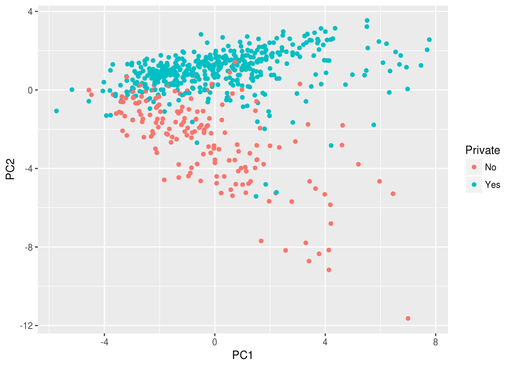

```r
library(ggplot2)
ggplot() + geom_point(data = transformed.main, aes(x = PC1, y = PC2, color = Private))
```

### Построение модели

Построим модель для предсказания типа колледжа (частный - государственный) по исходным данным, без преобразования

```r
library(e1071)
svm_model0 <- svm(Private~., data = data.main)
```

Результаты на обучающей

```r
svm.Pred<-predict(svm_model0, data.main, probability=FALSE)
confusionMatrix(svm.Pred,data.main$Private)
```

```
## Confusion Matrix and Statistics
##
##           Reference
## Prediction  No Yes
##        No  150   6
##        Yes  21 445
##
##                Accuracy : 0.9566
##                  95% CI : (0.9375, 0.9712)
##     No Information Rate : 0.7251
##     P-Value [Acc > NIR] : < 2.2e-16
##
##                   Kappa : 0.8881
##  Mcnemar's Test P-Value : 0.007054
##
##             Sensitivity : 0.8772
##             Specificity : 0.9867
##          Pos Pred Value : 0.9615
##          Neg Pred Value : 0.9549
##              Prevalence : 0.2749
##          Detection Rate : 0.2412
##    Detection Prevalence : 0.2508
##       Balanced Accuracy : 0.9319
##
##        'Positive' Class : No
##
```

и тестовой выборках

```r
svm.Pred<-predict(svm_model0, data.test, probability=FALSE)
confusionMatrix(svm.Pred,data.test$Private)
```

```
## Confusion Matrix and Statistics
##
##           Reference
## Prediction  No Yes
##        No   33   4
##        Yes   8 110
##
##                Accuracy : 0.9226
##                  95% CI : (0.8687, 0.9594)
##     No Information Rate : 0.7355
##     P-Value [Acc > NIR] : 3.27e-09
##
##                   Kappa : 0.7946
##  Mcnemar's Test P-Value : 0.3865
##
##             Sensitivity : 0.8049
##             Specificity : 0.9649
##          Pos Pred Value : 0.8919
##          Neg Pred Value : 0.9322
##              Prevalence : 0.2645
##          Detection Rate : 0.2129
##    Detection Prevalence : 0.2387
##       Balanced Accuracy : 0.8849
##
##        'Positive' Class : No
##
```

А теперь посмотрим на результаты для данных со сниженной размерностью

```r
svm_model <- svm(Private~., data = transformed.main)
```

Результаты на обучающей

```r
svm.Pred<-predict(svm_model, transformed.main, probability=FALSE)
confusionMatrix(svm.Pred,transformed.main$Private)
```

```
## Confusion Matrix and Statistics
##
##           Reference
## Prediction  No Yes
##        No  149   3
##        Yes  22 448
##
##                Accuracy : 0.9598
##                  95% CI : (0.9412, 0.9738)
##     No Information Rate : 0.7251
##     P-Value [Acc > NIR] : < 2.2e-16
##
##                   Kappa : 0.8956
##  Mcnemar's Test P-Value : 0.0003182
##
##             Sensitivity : 0.8713
##             Specificity : 0.9933
##          Pos Pred Value : 0.9803
##          Neg Pred Value : 0.9532
##              Prevalence : 0.2749
##          Detection Rate : 0.2395
##    Detection Prevalence : 0.2444
##       Balanced Accuracy : 0.9323
##
##        'Positive' Class : No
##
```

и тестовой выборках

```r
svm.Pred<-predict(svm_model, transformed.test, probability=FALSE)
confusionMatrix(svm.Pred,transformed.test$Private)
```

```
## Confusion Matrix and Statistics
##
##           Reference
## Prediction  No Yes
##        No   33   3
##        Yes   8 111
##
##                Accuracy : 0.929
##                  95% CI : (0.8766, 0.964)
##     No Information Rate : 0.7355
##     P-Value [Acc > NIR] : 7.385e-10
##
##                   Kappa : 0.8102
##  Mcnemar's Test P-Value : 0.2278
##
##             Sensitivity : 0.8049
##             Specificity : 0.9737
##          Pos Pred Value : 0.9167
##          Neg Pred Value : 0.9328
##              Prevalence : 0.2645
##          Detection Rate : 0.2129
##    Detection Prevalence : 0.2323
##       Balanced Accuracy : 0.8893
##
##        'Positive' Class : No
##
```

Уменьшим количество компонент

```r
preprocessParams2 <- preProcess(data.main,
                                method=c("center", "scale", "pca"), thresh = 0.8)
preprocessParams2
```

```
## Created from 622 samples and 18 variables
##
## Pre-processing:
##   - centered (17)
##   - ignored (1)
##   - principal component signal extraction (17)
##   - scaled (17)
##
## PCA needed 6 components to capture 80 percent of the variance
```

```r
# transform the dataset using the parameters
transformed.main2 <- predict(preprocessParams2, data.main)
transformed.test2 <- predict(preprocessParams2, data.test)
```

А теперь посмотрим на результаты для модели с меньшим количеством переменных

```r
svm_model2 <- svm(Private~., data = transformed.main2)
```

Результаты на обучающей

```r
svm.Pred<-predict(svm_model2, transformed.main2, probability=FALSE)
confusionMatrix(svm.Pred,transformed.main2$Private)
```

```
## Confusion Matrix and Statistics
##
##           Reference
## Prediction  No Yes
##        No  146   7
##        Yes  25 444
##
##                Accuracy : 0.9486
##                  95% CI : (0.9281, 0.9645)
##     No Information Rate : 0.7251
##     P-Value [Acc > NIR] : < 2.2e-16
##
##                   Kappa : 0.8666
##  Mcnemar's Test P-Value : 0.002654
##
##             Sensitivity : 0.8538
##             Specificity : 0.9845
##          Pos Pred Value : 0.9542
##          Neg Pred Value : 0.9467
##              Prevalence : 0.2749
##          Detection Rate : 0.2347
##    Detection Prevalence : 0.2460
##       Balanced Accuracy : 0.9191
##
##        'Positive' Class : No
##
```

и тестовой выборках

```r
svm.Pred<-predict(svm_model2, transformed.test2, probability=FALSE)
confusionMatrix(svm.Pred,transformed.test2$Private)
```

```
## Confusion Matrix and Statistics
##
##           Reference
## Prediction  No Yes
##        No   34   4
##        Yes   7 110
##
##                Accuracy : 0.929
##                  95% CI : (0.8766, 0.964)
##     No Information Rate : 0.7355
##     P-Value [Acc > NIR] : 7.385e-10
##
##                   Kappa : 0.8132
##  Mcnemar's Test P-Value : 0.5465
##
##             Sensitivity : 0.8293
##             Specificity : 0.9649
##          Pos Pred Value : 0.8947
##          Neg Pred Value : 0.9402
##              Prevalence : 0.2645
##          Detection Rate : 0.2194
##    Detection Prevalence : 0.2452
##       Balanced Accuracy : 0.8971
##
##        'Positive' Class : No
##
```

- Что вы можете сказать про результаты?

**Ваша очередь:**

- на этих же данных постройте модель, предсказывающую количество поданных заявлений (Apps)
- на этих же данных постройте модель, предсказывающую graduation rate

При предсказании числовой переменной не забудьте убрать ее из PCA

```r
preprocessParams3 <- preProcess(dplyr::select(data.main, -Apps),
                                method=c("center", "scale", "pca"), thresh = 0.8)

# transform the dataset using the parameters
transformed.main3 <- predict(preprocessParams3, data.main)
transformed.test3 <- predict(preprocessParams3, data.test)
```